# Graph Examples

# Graphs in R

This document is meant to be a toolkit for creating graphs in R. Below are a series of example graphs designed to be easily modified and used with your data.

The graphing package used is called `ggplot2`. This can be loaded on it’s own or as part of the the `tidyverse` package.

It’s creators describe `ggplot2` as a [system for declaratively creating graphics](https://ggplot2.tidyverse.org/). You provide ggplot2 your data and some properties you want your graph to have, and it will create it for you.

There are a lot of resources and in depth guides available for `ggplot2` written by the people who produced it. Instead of reproducing these, this document provides some templates for graphs so we can create visually consistent graphs quickly.

If you are interested in learning more about `ggplot2` the following resources are a good place to start:

- The data visualisation chapter of [R for Data Science](https://r4ds.had.co.nz/data-visualisation.html)
- The DataCamp `ggplot2` [course](https://www.datacamp.com/courses/data-visualization-with-ggplot2-1)
- The `ggplot2` [cheatsheet](https://www.rstudio.com/wp-content/uploads/2015/03/ggplot2-cheatsheet.pdf)
- The `ggplot2` [CRAN page](https://cran.r-project.org/web/packages/ggplot2/ggplot2.pdf)
- The help function in RStudio. This will give you the specific arguments you need for each element, i.e. `?geom_col()`

## Read in data

The charts below use the example data created below.

```r
x <- 20
exampleData <- tibble(values = runif(20, 1, x),
                      type = c(rep(c("A"), x/2), rep(c("B"), x/2)),
                      date = rep(seq(as.Date("2016/12/01"), by = "month", length.out = x/2), 2))
```

Real data will likely need some transformation before it can be plotted.

## DHSC_style

These graphs all use a function called `dh_style()`. This ensures they all look consistent. To import this fuction use:

`source("G:/EOR3/HCAT/Analytical - misc/Data Science/dh-plot.R")`

This will make `dhsc_style` available. It also gives you quicker access to the colours defined in the DHSC publishing guidlines. To see these colours use the function `list_dhsc_colours()`.

`dhsc_style` is mostly copied from the [BBC’s graphing package](https://github.com/bbc/bbplot/tree/master/R).

## Bar Charts

### Simple Bar Chart

This simple chart uses `geom_col` to create a bar chart. The `fill` argument defines the colour of the bars.

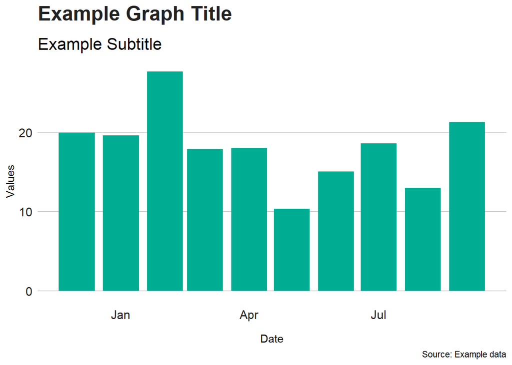

```r
ggplot(data = exampleData) +

  geom_col(aes(x = date, y = values), fill = dh_Teal) +

    labs(title = "Example Graph Title",
       subtitle = "Example Subtitle",
       caption = "Source: Example data") +
  xlab("Date") +
  ylab("Values") +

  #theme_gov()
  dhsc_style()
```

## Stacked Bar Chart

The main difference between this graph and the one above is that the `fill` argument is inside the `aes()`. This is the aesthetics function which describes how the data is mapped onto the graph. Including the `fill` tells ggplot that the `fill` parameter should differentiate on the variable `type`. The colour of the bars is then defined in the function `scale_fill_manual`.

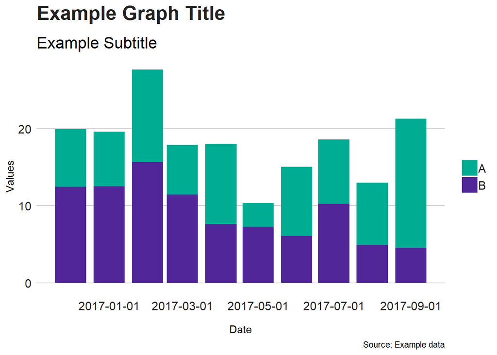

```r
ggplot(data = exampleData) +

  geom_col(aes(x = date, y = values, fill = type)) +

  scale_fill_manual(values = (c(dh_Teal, dh_Purple))) +

  labs(title = "Example Graph Title",
       subtitle = "Example Subtitle",
       caption = "Source: Example data") +
  xlab("Date") +
  ylab("Values") +
  scale_x_date(date_breaks = "2 months") +

  #theme_gov()
  dhsc_style()
```

## Comparative Bar Chart

This chart is the same as above except for the argument `position = position_dodge(width = 20)`. This tells ggplot that you want the bars side by side instead of stacked. You can adjust the number to change the positioning of the bars.

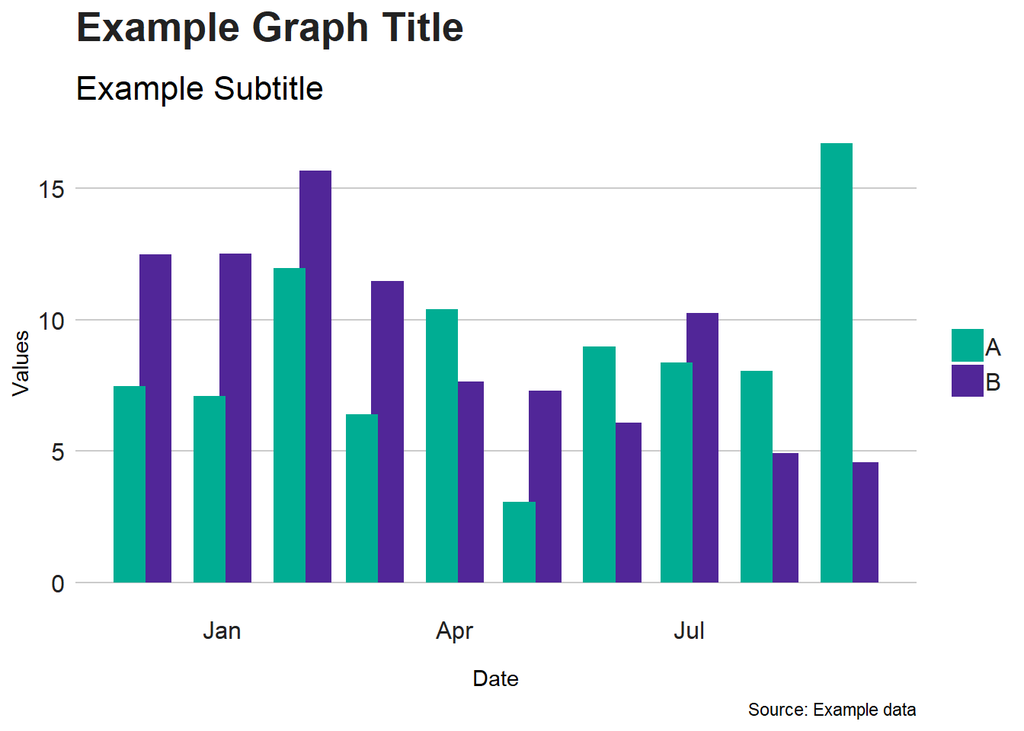

```r
ggplot(data = exampleData) +

  geom_col(aes(x = date, y = values, fill = type), position = position_dodge(width = 20)) +

  scale_fill_manual(values = (c(dh_Teal, dh_Purple))) +

  labs(title = "Example Graph Title",
       subtitle = "Example Subtitle",
       caption = "Source: Example data") +
  xlab("Date") +
  ylab("Values") +

  #theme_gov()
  dhsc_style()
```

## Faceted Bar Chart

This graph uses `facet_wrap` to create two charts side by side, one for each `type`.

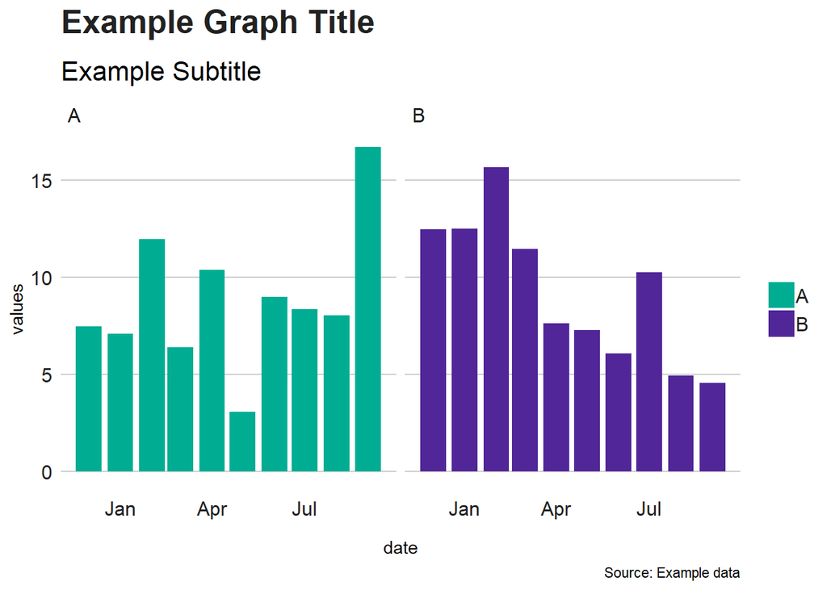

```r
ggplot(data = exampleData) +

  geom_col(aes(x = date, y = values, fill = type)) +

  facet_wrap(vars(type)) +

  scale_fill_manual(values = (c(dh_Teal, dh_Purple))) +

  labs(title = "Example Graph Title",
       subtitle = "Example Subtitle",
       xlab = "Values",
       ylab = "Date",
       caption = "Source: Example data") +

  #theme_gov()
  dhsc_style()
```

# Line Charts

This chart uses several `geom_()` objects to add different elements to the chart.

- `geom_line` is the line graph element
- `geom_point` adds the point elements
- `geom_text` adds the values at ech data point
- `geom_hline` adds a horziontal line on a specfic y intercept value

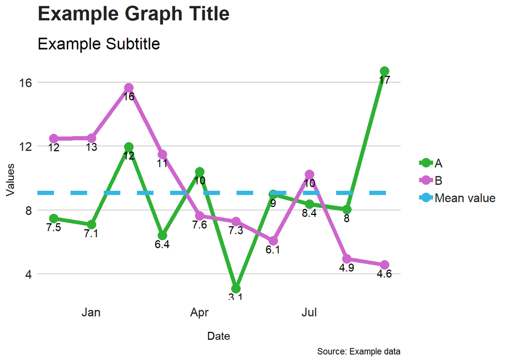

```r
ggplot(data = exampleData) +

  geom_line(aes(x = date, y = values, colour = type), size = 2) +

  geom_point(aes(x = date, y = values, colour = type), size = 4, shape = 16) +

  geom_text(aes(x = date, y = values, label = signif(values, digits = 2), vjust = 1.5),show.legend = FALSE) +

  geom_hline(aes(yintercept = mean(values), colour = "Mean value"), size = 2, linetype = "dashed") +

  scale_colour_manual(values = (c(dh_GreenL, dh_Pink, dh_Sky))) +

  labs(title = "Example Graph Title",
       subtitle = "Example Subtitle",
       caption = "Source: Example data") +
  xlab("Date") +
  ylab("Values") +

  #theme_gov()
  dhsc_style()
```

This line chart moves the data argument from the `ggplot()` object to the `geom_()` objects. This means we can plot different data on different lines.

Here we have two `geom_line()` objects, each with filtered data sets. One of these objects plots the points before a date, with a dashed line, one plots all the objects after the date with a filled line.

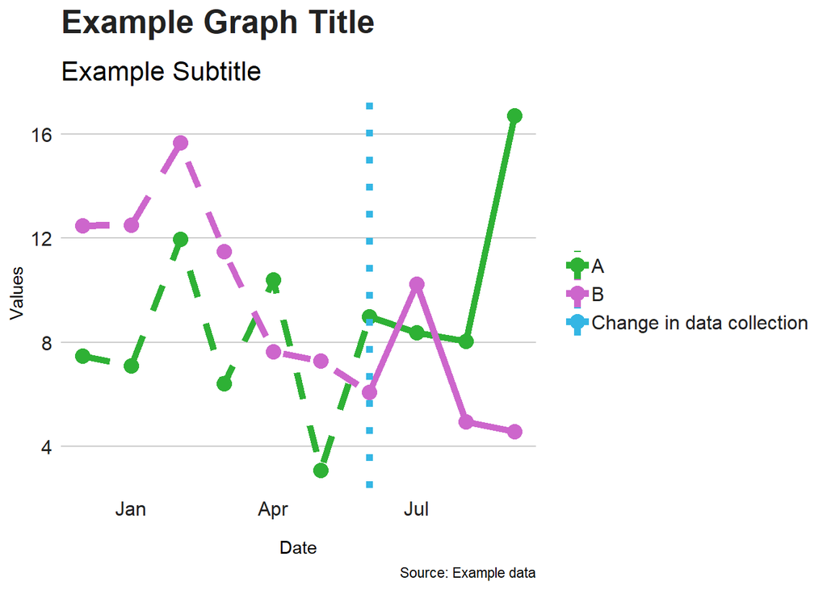

```r
thresholdDate <- as.Date("2017-06-01")

ggplot() +

  geom_line(data = filter(exampleData, date >= thresholdDate), aes(x = date, y = values, colour = type), size = 2) +

  geom_line(data = filter(exampleData, date <= thresholdDate), aes(x = date, y = values, colour = type), size = 2, linetype = "dashed") +

  geom_point(data = exampleData, aes(x = date, y = values, colour = type), size = 4, shape = 16) +

  geom_vline(data = exampleData, aes(xintercept = thresholdDate, colour = "Change in data collection"), size = 2, linetype = "dotted") +

  scale_colour_manual(values = (c(dh_GreenL, dh_Pink, dh_Sky))) +

  labs(title = "Example Graph Title",
       subtitle = "Example Subtitle",
       caption = "Source: Example data") +
  xlab("Date") +
  ylab("Values") +

  #theme_gov()
  dhsc_style()
```

# Area Chart

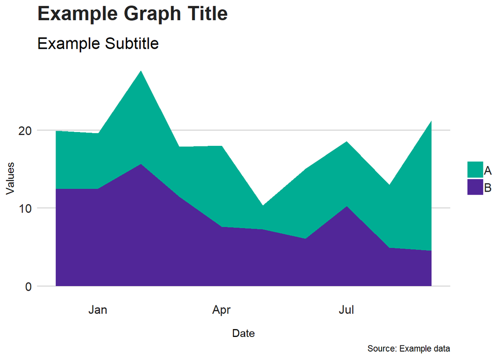

```r
ggplot(data = exampleData) +

  geom_area(aes(x = date, y = values, fill = type)) +

  scale_fill_manual(values = (c(dh_Teal, dh_Purple))) +

  labs(title = "Example Graph Title",
       subtitle = "Example Subtitle",
       caption = "Source: Example data") +
  xlab("Date") +
  ylab("Values") +

  #theme_gov()
  dhsc_style()
```

# Mixed bar and Line Chart

The creator of ggplot2 doesn’t agree with having two independent axis on the same graph. As a result creating graphs with 2 y-axis is more complicated than the above graphs.

Again we have different data arguments for each `geom_()` object, with the `geom_line` data having a transformation into percentages.

In `ggplot` the second y-axis needs to be a direct transformation of the first. To get around this we are using a variable I have called `scaleFactor`. If you divide your y-axis values by this number, and multiply your first y-axis scale by the same number, the second y-axis will give the correct scale. This is obviously not ideal.

The object that gives the the second y axis is `scale_y_continuous()`. The first argument is a formula that describes the transformation of the first y-axis that will be the scale of the second.

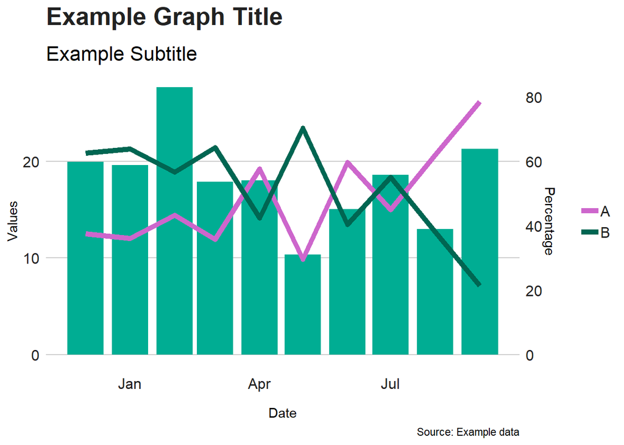

```r
scaleFactor <- 3

ggplot() +

  geom_col(data = exampleData %>%
             group_by(date) %>%
             summarise(total = sum(values)),
           aes(x = date, y = total), fill = dh_Teal) +

  geom_line(data = exampleData %>%
              group_by(date) %>%
              mutate(percent = values/sum(values)*100),
            aes(x = date, y = percent/scaleFactor, colour = type), size = 2) +

  scale_colour_manual(values = (c(dh_Pink, dh_GreenD))) +

  scale_y_continuous(sec.axis = sec_axis(~.*scaleFactor, name = "Percentage")) +

  labs(title = "Example Graph Title",
       subtitle = "Example Subtitle",
       caption = "Source: Example data") +
  xlab("Date") +
  ylab("Values") +

  #theme_gov()
  dhsc_style()
```